# Risk Factor Analysis

## Outcome Variable

**Outcome Variable:** haz

## Predictor Variables

**Intervention Variable:** hfoodsec

**Adjustment Set:**

- arm
- sex
- W_mage
- meducyrs
- feducyrs
- hhwealth_quart
- vagbrth
- W_nrooms
- W_nchldlt5
- brthmon
- W_parity
- impfloor
- impsan
- safeh20
- delta_W_mage
- delta_meducyrs
- delta_feducyrs
- delta_hhwealth_quart
- delta_vagbrth
- delta_W_nrooms
- delta_W_nchldlt5
- delta_brthmon
- delta_W_parity
- delta_impfloor
- delta_impsan
- delta_safeh20

## Stratifying Variables

The analysis was stratified on these variable(s):

- agecat
- studyid
- country

## Data Summary

| agecat | studyid | country | hfoodsec | n_cell | n |
| --- | --- | --- | --- | --- | --- |
| Birth | ki0047075b-MAL-ED | BANGLADESH | Food Secure | 157 | 188 |
| Birth | ki0047075b-MAL-ED | BANGLADESH | Mildly Food Insecure | 4 | 188 |
| Birth | ki0047075b-MAL-ED | BANGLADESH | Food Insecure | 27 | 188 |
| Birth | ki0047075b-MAL-ED | BRAZIL | Food Secure | 0 | 105 |
| Birth | ki0047075b-MAL-ED | BRAZIL | Mildly Food Insecure | 11 | 105 |
| Birth | ki0047075b-MAL-ED | BRAZIL | Food Insecure | 94 | 105 |
| Birth | ki0047075b-MAL-ED | INDIA | Food Secure | 154 | 170 |
| Birth | ki0047075b-MAL-ED | INDIA | Mildly Food Insecure | 2 | 170 |
| Birth | ki0047075b-MAL-ED | INDIA | Food Insecure | 14 | 170 |
| Birth | ki0047075b-MAL-ED | NEPAL | Food Secure | 76 | 98 |
| Birth | ki0047075b-MAL-ED | NEPAL | Mildly Food Insecure | 9 | 98 |
| Birth | ki0047075b-MAL-ED | NEPAL | Food Insecure | 13 | 98 |
| Birth | ki0047075b-MAL-ED | PERU | Food Secure | 27 | 107 |
| Birth | ki0047075b-MAL-ED | PERU | Mildly Food Insecure | 25 | 107 |
| Birth | ki0047075b-MAL-ED | PERU | Food Insecure | 55 | 107 |
| Birth | ki0047075b-MAL-ED | SOUTH AFRICA | Food Secure | 107 | 195 |
| Birth | ki0047075b-MAL-ED | SOUTH AFRICA | Mildly Food Insecure | 17 | 195 |
| Birth | ki0047075b-MAL-ED | SOUTH AFRICA | Food Insecure | 71 | 195 |
| Birth | ki1017093-NIH-Birth | BANGLADESH | Food Secure | 3 | 28 |
| Birth | ki1017093-NIH-Birth | BANGLADESH | Mildly Food Insecure | 21 | 28 |
| Birth | ki1017093-NIH-Birth | BANGLADESH | Food Insecure | 4 | 28 |
| Birth | ki1017093c-NIH-Crypto | BANGLADESH | Food Secure | 14 | 27 |
| Birth | ki1017093c-NIH-Crypto | BANGLADESH | Mildly Food Insecure | 9 | 27 |
| Birth | ki1017093c-NIH-Crypto | BANGLADESH | Food Insecure | 4 | 27 |
| Birth | kiGH5241-JiVitA-3 | BANGLADESH | Food Secure | 5997 | 12605 |
| Birth | kiGH5241-JiVitA-3 | BANGLADESH | Mildly Food Insecure | 4335 | 12605 |
| Birth | kiGH5241-JiVitA-3 | BANGLADESH | Food Insecure | 2273 | 12605 |
| Birth | kiGH5241-JiVitA-4 | BANGLADESH | Food Secure | 396 | 819 |
| Birth | kiGH5241-JiVitA-4 | BANGLADESH | Mildly Food Insecure | 309 | 819 |
| Birth | kiGH5241-JiVitA-4 | BANGLADESH | Food Insecure | 114 | 819 |

[output cut: 66 more lines]

The following strata were considered:

- agecat: 24 months, studyid: ki0047075b-MAL-ED, country: BANGLADESH
- agecat: 24 months, studyid: ki0047075b-MAL-ED, country: BRAZIL
- agecat: 24 months, studyid: ki0047075b-MAL-ED, country: INDIA
- agecat: 24 months, studyid: ki0047075b-MAL-ED, country: NEPAL
- agecat: 24 months, studyid: ki0047075b-MAL-ED, country: PERU
- agecat: 24 months, studyid: ki0047075b-MAL-ED, country: SOUTH AFRICA
- agecat: 24 months, studyid: ki1017093-NIH-Birth, country: BANGLADESH
- agecat: 24 months, studyid: ki1017093c-NIH-Crypto, country: BANGLADESH
- agecat: 24 months, studyid: ki1113344-GMS-Nepal, country: NEPAL
- agecat: 24 months, studyid: kiGH5241-JiVitA-3, country: BANGLADESH
- agecat: 24 months, studyid: kiGH5241-JiVitA-4, country: BANGLADESH
- agecat: 6 months, studyid: ki0047075b-MAL-ED, country: BANGLADESH
- agecat: 6 months, studyid: ki0047075b-MAL-ED, country: BRAZIL
- agecat: 6 months, studyid: ki0047075b-MAL-ED, country: INDIA
- agecat: 6 months, studyid: ki0047075b-MAL-ED, country: NEPAL
- agecat: 6 months, studyid: ki0047075b-MAL-ED, country: PERU
- agecat: 6 months, studyid: ki0047075b-MAL-ED, country: SOUTH AFRICA
- agecat: 6 months, studyid: ki1017093-NIH-Birth, country: BANGLADESH
- agecat: 6 months, studyid: ki1017093c-NIH-Crypto, country: BANGLADESH
- agecat: 6 months, studyid: ki1113344-GMS-Nepal, country: NEPAL
- agecat: 6 months, studyid: kiGH5241-JiVitA-3, country: BANGLADESH
- agecat: 6 months, studyid: kiGH5241-JiVitA-4, country: BANGLADESH
- agecat: Birth, studyid: ki0047075b-MAL-ED, country: BANGLADESH
- agecat: Birth, studyid: ki0047075b-MAL-ED, country: BRAZIL
- agecat: Birth, studyid: ki0047075b-MAL-ED, country: INDIA
- agecat: Birth, studyid: ki0047075b-MAL-ED, country: NEPAL
- agecat: Birth, studyid: ki0047075b-MAL-ED, country: PERU
- agecat: Birth, studyid: ki0047075b-MAL-ED, country: SOUTH AFRICA
- agecat: Birth, studyid: ki1017093-NIH-Birth, country: BANGLADESH
- agecat: Birth, studyid: ki1017093c-NIH-Crypto, country: BANGLADESH
- agecat: Birth, studyid: kiGH5241-JiVitA-3, country: BANGLADESH
- agecat: Birth, studyid: kiGH5241-JiVitA-4, country: BANGLADESH

### Dropped Strata

Some strata were dropped due to rare outcomes:

- agecat: Birth, studyid: ki0047075b-MAL-ED, country: BANGLADESH
- agecat: Birth, studyid: ki0047075b-MAL-ED, country: BRAZIL
- agecat: Birth, studyid: ki0047075b-MAL-ED, country: INDIA
- agecat: Birth, studyid: ki1017093-NIH-Birth, country: BANGLADESH
- agecat: Birth, studyid: ki1017093c-NIH-Crypto, country: BANGLADESH
- agecat: 6 months, studyid: ki0047075b-MAL-ED, country: BANGLADESH
- agecat: 6 months, studyid: ki0047075b-MAL-ED, country: BRAZIL
- agecat: 24 months, studyid: ki0047075b-MAL-ED, country: BANGLADESH
- agecat: 24 months, studyid: ki0047075b-MAL-ED, country: BRAZIL

## Methods Detail

We’re interested in the causal parameters $E[Y_a]$ for all values of $a \in \mathcal{A}$. These parameters represent the mean outcome if, possibly contrary to fact, we intervened to set all units to have $A=a$. Under the randomization and positivity assumptions, these are identified by the statistical parameters $\psi_a=E_W[E_{Y|A,W}(Y|A=a,W)]$. In addition, we’re interested in the mean of $Y$, $E[Y]$ under no intervention (the observed mean). We will estimate these parameters by using SuperLearner to fit the relevant likelihood factors – $E_{Y|A,W}(Y|A=a,W)$ and $p(A=a|W)$, and then updating our likelihood fit using a joint TMLE.

For unadjusted analyses ($W=\{\}$), initial likelihoods were estimated using Lrnr_glm to estimate the simple $E(Y|A)$ and Lrnr_mean to estimate $p(A)$. For adjusted analyses, a small library containing Lrnr_glmnet, Lrnr_xgboost, and Lrnr_mean was used.

Having estimated these parameters, we will then use the delta method to estimate relative risks and attributable risks relative to a prespecified baseline level of $A$.

# Results Detail

## Results Plots

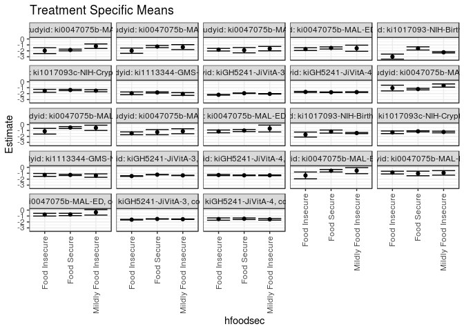

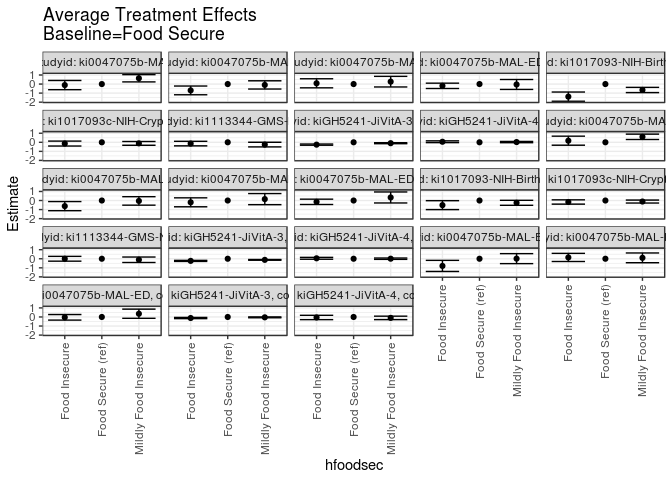

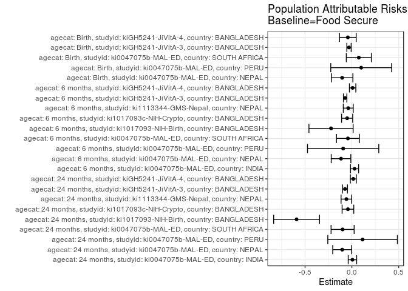

## Results Table

### Parameter: TSM

| agecat | studyid | country | intervention_level | baseline_level | estimate | ci_lower | ci_upper |
| --- | --- | --- | --- | --- | --- | --- | --- |
| Birth | ki0047075b-MAL-ED | NEPAL | Food Secure | NA | -0.5764474 | -0.7891541 | -0.3637406 |
| Birth | ki0047075b-MAL-ED | NEPAL | Mildly Food Insecure | NA | -0.5644444 | -1.0737762 | -0.0551126 |
| Birth | ki0047075b-MAL-ED | NEPAL | Food Insecure | NA | -1.3684615 | -1.9425417 | -0.7943814 |
| Birth | ki0047075b-MAL-ED | PERU | Food Secure | NA | -1.0383178 | -1.4236967 | -0.6529389 |
| Birth | ki0047075b-MAL-ED | PERU | Mildly Food Insecure | NA | -0.9393761 | -1.3200487 | -0.5587035 |
| Birth | ki0047075b-MAL-ED | PERU | Food Insecure | NA | -0.8918689 | -1.1237172 | -0.6600206 |
| Birth | ki0047075b-MAL-ED | SOUTH AFRICA | Food Secure | NA | -0.7390075 | -0.9366815 | -0.5413336 |
| Birth | ki0047075b-MAL-ED | SOUTH AFRICA | Mildly Food Insecure | NA | -0.3800358 | -0.8427863 | 0.0827147 |
| Birth | ki0047075b-MAL-ED | SOUTH AFRICA | Food Insecure | NA | -0.7747110 | -1.0057856 | -0.5436365 |
| Birth | kiGH5241-JiVitA-3 | BANGLADESH | Food Secure | NA | -1.4973163 | -1.5288865 | -1.4657461 |
| Birth | kiGH5241-JiVitA-3 | BANGLADESH | Mildly Food Insecure | NA | -1.5358478 | -1.5756730 | -1.4960225 |
| Birth | kiGH5241-JiVitA-3 | BANGLADESH | Food Insecure | NA | -1.6132628 | -1.6684803 | -1.5580453 |
| Birth | kiGH5241-JiVitA-4 | BANGLADESH | Food Secure | NA | -1.4571462 | -1.5905718 | -1.3237205 |
| Birth | kiGH5241-JiVitA-4 | BANGLADESH | Mildly Food Insecure | NA | -1.5574279 | -1.6918424 | -1.4230134 |
| Birth | kiGH5241-JiVitA-4 | BANGLADESH | Food Insecure | NA | -1.5120421 | -1.7082022 | -1.3158820 |
| 6 months | ki0047075b-MAL-ED | INDIA | Food Secure | NA | -1.2392193 | -1.3694179 | -1.1090207 |
| 6 months | ki0047075b-MAL-ED | INDIA | Mildly Food Insecure | NA | -0.6360000 | -0.9019405 | -0.3700595 |
| 6 months | ki0047075b-MAL-ED | INDIA | Food Insecure | NA | -1.0620588 | -1.5420342 | -0.5820835 |
| 6 months | ki0047075b-MAL-ED | NEPAL | Food Secure | NA | -0.5095381 | -0.6689573 | -0.3501189 |
| 6 months | ki0047075b-MAL-ED | NEPAL | Mildly Food Insecure | NA | -0.5559316 | -0.9958463 | -0.1160168 |
| 6 months | ki0047075b-MAL-ED | NEPAL | Food Insecure | NA | -1.1293978 | -1.6065584 | -0.6522371 |
| 6 months | ki0047075b-MAL-ED | PERU | Food Secure | NA | -1.2860064 | -1.7202449 | -0.8517680 |
| 6 months | ki0047075b-MAL-ED | PERU | Mildly Food Insecure | NA | -1.1303830 | -1.5472345 | -0.7135314 |
| 6 months | ki0047075b-MAL-ED | PERU | Food Insecure | NA | -1.4837531 | -1.7218113 | -1.2456949 |
| 6 months | ki0047075b-MAL-ED | SOUTH AFRICA | Food Secure | NA | -1.0117173 | -1.1873417 | -0.8360930 |
| 6 months | ki0047075b-MAL-ED | SOUTH AFRICA | Mildly Food Insecure | NA | -0.6749248 | -1.2535618 | -0.0962878 |
| 6 months | ki0047075b-MAL-ED | SOUTH AFRICA | Food Insecure | NA | -1.1580205 | -1.3922668 | -0.9237742 |
| 6 months | ki1017093-NIH-Birth | BANGLADESH | Food Secure | NA | -1.1848511 | -1.4427590 | -0.9269431 |
| 6 months | ki1017093-NIH-Birth | BANGLADESH | Mildly Food Insecure | NA | -1.4364988 | -1.5330817 | -1.3399158 |
| 6 months | ki1017093-NIH-Birth | BANGLADESH | Food Insecure | NA | -1.6940554 | -2.1144752 | -1.2736357 |
| 6 months | ki1017093c-NIH-Crypto | BANGLADESH | Food Secure | NA | -1.1481203 | -1.2405205 | -1.0557202 |
| 6 months | ki1017093c-NIH-Crypto | BANGLADESH | Mildly Food Insecure | NA | -1.2606604 | -1.3947222 | -1.1265986 |
| 6 months | ki1017093c-NIH-Crypto | BANGLADESH | Food Insecure | NA | -1.3102839 | -1.5278175 | -1.0927502 |
| 6 months | ki1113344-GMS-Nepal | NEPAL | Food Secure | NA | -1.2850297 | -1.3795486 | -1.1905109 |
| 6 months | ki1113344-GMS-Nepal | NEPAL | Mildly Food Insecure | NA | -1.3954273 | -1.6813705 | -1.1094841 |
| 6 months | ki1113344-GMS-Nepal | NEPAL | Food Insecure | NA | -1.2868653 | -1.5313384 | -1.0423923 |
| 6 months | kiGH5241-JiVitA-3 | BANGLADESH | Food Secure | NA | -1.2412546 | -1.2703907 | -1.2121186 |
| 6 months | kiGH5241-JiVitA-3 | BANGLADESH | Mildly Food Insecure | NA | -1.3644282 | -1.3964787 | -1.3323777 |
| 6 months | kiGH5241-JiVitA-3 | BANGLADESH | Food Insecure | NA | -1.4754940 | -1.5287173 | -1.4222708 |
| 6 months | kiGH5241-JiVitA-4 | BANGLADESH | Food Secure | NA | -1.3527220 | -1.4046911 | -1.3007528 |
| 6 months | kiGH5241-JiVitA-4 | BANGLADESH | Mildly Food Insecure | NA | -1.3474810 | -1.4067580 | -1.2882041 |
| 6 months | kiGH5241-JiVitA-4 | BANGLADESH | Food Insecure | NA | -1.3043784 | -1.3936989 | -1.2150579 |
| 24 months | ki0047075b-MAL-ED | INDIA | Food Secure | NA | -1.8536842 | -1.9918894 | -1.7154790 |
| 24 months | ki0047075b-MAL-ED | INDIA | Mildly Food Insecure | NA | -1.2150000 | -1.5912720 | -0.8387280 |
| 24 months | ki0047075b-MAL-ED | INDIA | Food Insecure | NA | -1.9661765 | -2.4561419 | -1.4762110 |
| 24 months | ki0047075b-MAL-ED | NEPAL | Food Secure | NA | -1.2743841 | -1.4597346 | -1.0890335 |
| 24 months | ki0047075b-MAL-ED | NEPAL | Mildly Food Insecure | NA | -1.3708056 | -1.7865772 | -0.9550341 |
| 24 months | ki0047075b-MAL-ED | NEPAL | Food Insecure | NA | -1.9733618 | -2.4169249 | -1.5297988 |
| 24 months | ki0047075b-MAL-ED | PERU | Food Secure | NA | -1.8904332 | -2.3358879 | -1.4449784 |
| 24 months | ki0047075b-MAL-ED | PERU | Mildly Food Insecure | NA | -1.6258408 | -1.9999858 | -1.2516957 |
| 24 months | ki0047075b-MAL-ED | PERU | Food Insecure | NA | -1.8062848 | -2.0274234 | -1.5851462 |
| 24 months | ki0047075b-MAL-ED | SOUTH AFRICA | Food Secure | NA | -1.5118475 | -1.6944841 | -1.3292109 |
| 24 months | ki0047075b-MAL-ED | SOUTH AFRICA | Mildly Food Insecure | NA | -1.5584466 | -2.0749483 | -1.0419449 |
| 24 months | ki0047075b-MAL-ED | SOUTH AFRICA | Food Insecure | NA | -1.7072471 | -1.9374767 | -1.4770175 |
| 24 months | ki1017093-NIH-Birth | BANGLADESH | Food Secure | NA | -1.5904241 | -1.8589242 | -1.3219239 |
| 24 months | ki1017093-NIH-Birth | BANGLADESH | Mildly Food Insecure | NA | -2.2434955 | -2.3514247 | -2.1355663 |
| 24 months | ki1017093-NIH-Birth | BANGLADESH | Food Insecure | NA | -2.9769986 | -3.4056420 | -2.5483552 |
| 24 months | ki1017093c-NIH-Crypto | BANGLADESH | Food Secure | NA | -1.3874920 | -1.4917516 | -1.2832325 |
| 24 months | ki1017093c-NIH-Crypto | BANGLADESH | Mildly Food Insecure | NA | -1.5067381 | -1.6870072 | -1.3264691 |
| 24 months | ki1017093c-NIH-Crypto | BANGLADESH | Food Insecure | NA | -1.5282594 | -1.7778164 | -1.2787025 |
| 24 months | ki1113344-GMS-Nepal | NEPAL | Food Secure | NA | -1.8073683 | -1.9085519 | -1.7061847 |
| 24 months | ki1113344-GMS-Nepal | NEPAL | Mildly Food Insecure | NA | -2.0625174 | -2.2979258 | -1.8271089 |
| 24 months | ki1113344-GMS-Nepal | NEPAL | Food Insecure | NA | -1.9501312 | -2.1807673 | -1.7194952 |
| 24 months | kiGH5241-JiVitA-3 | BANGLADESH | Food Secure | NA | -1.9351931 | -1.9743771 | -1.8960092 |
| 24 months | kiGH5241-JiVitA-3 | BANGLADESH | Mildly Food Insecure | NA | -2.0348566 | -2.0793770 | -1.9903363 |
| 24 months | kiGH5241-JiVitA-3 | BANGLADESH | Food Insecure | NA | -2.1959918 | -2.2551337 | -2.1368498 |
| 24 months | kiGH5241-JiVitA-4 | BANGLADESH | Food Secure | NA | -1.7730678 | -1.8221650 | -1.7239706 |
| 24 months | kiGH5241-JiVitA-4 | BANGLADESH | Mildly Food Insecure | NA | -1.7484685 | -1.8036266 | -1.6933103 |
| 24 months | kiGH5241-JiVitA-4 | BANGLADESH | Food Insecure | NA | -1.7145746 | -1.8015676 | -1.6275817 |

### Parameter: E(Y)

| agecat | studyid | country | intervention_level | baseline_level | estimate | ci_lower | ci_upper |
| --- | --- | --- | --- | --- | --- | --- | --- |
| Birth | ki0047075b-MAL-ED | NEPAL | NA | NA | -0.6804082 | -0.8755126 | -0.4853037 |
| Birth | ki0047075b-MAL-ED | PERU | NA | NA | -0.9387850 | -1.1159974 | -0.7615727 |
| Birth | ki0047075b-MAL-ED | SOUTH AFRICA | NA | NA | -0.6647692 | -0.8062103 | -0.5233282 |
| Birth | kiGH5241-JiVitA-3 | BANGLADESH | NA | NA | -1.5280452 | -1.5507110 | -1.5053794 |
| Birth | kiGH5241-JiVitA-4 | BANGLADESH | NA | NA | -1.5000733 | -1.5844715 | -1.4156751 |
| 6 months | ki0047075b-MAL-ED | INDIA | NA | NA | -1.2107862 | -1.3345960 | -1.0869764 |
| 6 months | ki0047075b-MAL-ED | NEPAL | NA | NA | -0.6253125 | -0.7752118 | -0.4754132 |
| 6 months | ki0047075b-MAL-ED | PERU | NA | NA | -1.3792042 | -1.5615886 | -1.1968198 |
| 6 months | ki0047075b-MAL-ED | SOUTH AFRICA | NA | NA | -1.0539803 | -1.1904887 | -0.9174718 |
| 6 months | ki1017093-NIH-Birth | BANGLADESH | NA | NA | -1.4073821 | -1.4960598 | -1.3187043 |
| 6 months | ki1017093c-NIH-Crypto | BANGLADESH | NA | NA | -1.1986783 | -1.2700937 | -1.1272630 |
| 6 months | ki1113344-GMS-Nepal | NEPAL | NA | NA | -1.3236269 | -1.4015413 | -1.2457125 |
| 6 months | kiGH5241-JiVitA-3 | BANGLADESH | NA | NA | -1.3131326 | -1.3362851 | -1.2899801 |
| 6 months | kiGH5241-JiVitA-4 | BANGLADESH | NA | NA | -1.3446891 | -1.3822219 | -1.3071564 |
| 24 months | ki0047075b-MAL-ED | INDIA | NA | NA | -1.8476415 | -1.9786652 | -1.7166178 |
| 24 months | ki0047075b-MAL-ED | NEPAL | NA | NA | -1.3776172 | -1.5402475 | -1.2149868 |
| 24 months | ki0047075b-MAL-ED | PERU | NA | NA | -1.7760748 | -1.9504595 | -1.6016900 |
| 24 months | ki0047075b-MAL-ED | SOUTH AFRICA | NA | NA | -1.6108333 | -1.7488019 | -1.4728648 |
| 24 months | ki1017093-NIH-Birth | BANGLADESH | NA | NA | -2.1807945 | -2.2835902 | -2.0779987 |
| 24 months | ki1017093c-NIH-Crypto | BANGLADESH | NA | NA | -1.4295331 | -1.5127726 | -1.3462935 |
| 24 months | ki1113344-GMS-Nepal | NEPAL | NA | NA | -1.8659973 | -1.9508504 | -1.7811442 |
| 24 months | kiGH5241-JiVitA-3 | BANGLADESH | NA | NA | -2.0089421 | -2.0368231 | -1.9810610 |
| 24 months | kiGH5241-JiVitA-4 | BANGLADESH | NA | NA | -1.7576915 | -1.7933270 | -1.7220560 |

### Parameter: ATE

| agecat | studyid | country | intervention_level | baseline_level | estimate | ci_lower | ci_upper |
| --- | --- | --- | --- | --- | --- | --- | --- |
| Birth | ki0047075b-MAL-ED | NEPAL | Food Secure | Food Secure | 0.0000000 | 0.0000000 | 0.0000000 |
| Birth | ki0047075b-MAL-ED | NEPAL | Mildly Food Insecure | Food Secure | 0.0120029 | -0.5399600 | 0.5639658 |
| Birth | ki0047075b-MAL-ED | NEPAL | Food Insecure | Food Secure | -0.7920142 | -1.4042332 | -0.1797951 |
| Birth | ki0047075b-MAL-ED | PERU | Food Secure | Food Secure | 0.0000000 | 0.0000000 | 0.0000000 |
| Birth | ki0047075b-MAL-ED | PERU | Mildly Food Insecure | Food Secure | 0.0989417 | -0.4393951 | 0.6372784 |
| Birth | ki0047075b-MAL-ED | PERU | Food Insecure | Food Secure | 0.1464489 | -0.3027399 | 0.5956377 |
| Birth | ki0047075b-MAL-ED | SOUTH AFRICA | Food Secure | Food Secure | 0.0000000 | 0.0000000 | 0.0000000 |
| Birth | ki0047075b-MAL-ED | SOUTH AFRICA | Mildly Food Insecure | Food Secure | 0.3589717 | -0.1470451 | 0.8649886 |
| Birth | ki0047075b-MAL-ED | SOUTH AFRICA | Food Insecure | Food Secure | -0.0357035 | -0.3418472 | 0.2704402 |
| Birth | kiGH5241-JiVitA-3 | BANGLADESH | Food Secure | Food Secure | 0.0000000 | 0.0000000 | 0.0000000 |
| Birth | kiGH5241-JiVitA-3 | BANGLADESH | Mildly Food Insecure | Food Secure | -0.0385314 | -0.0878464 | 0.0107835 |
| Birth | kiGH5241-JiVitA-3 | BANGLADESH | Food Insecure | Food Secure | -0.1159465 | -0.1784483 | -0.0534447 |
| Birth | kiGH5241-JiVitA-4 | BANGLADESH | Food Secure | Food Secure | 0.0000000 | 0.0000000 | 0.0000000 |
| Birth | kiGH5241-JiVitA-4 | BANGLADESH | Mildly Food Insecure | Food Secure | -0.1002817 | -0.2887852 | 0.0882217 |
| Birth | kiGH5241-JiVitA-4 | BANGLADESH | Food Insecure | Food Secure | -0.0548959 | -0.2939587 | 0.1841669 |
| 6 months | ki0047075b-MAL-ED | INDIA | Food Secure | Food Secure | 0.0000000 | 0.0000000 | 0.0000000 |
| 6 months | ki0047075b-MAL-ED | INDIA | Mildly Food Insecure | Food Secure | 0.6032193 | 0.3071180 | 0.8993206 |
| 6 months | ki0047075b-MAL-ED | INDIA | Food Insecure | Food Secure | 0.1771605 | -0.3201603 | 0.6744813 |
| 6 months | ki0047075b-MAL-ED | NEPAL | Food Secure | Food Secure | 0.0000000 | 0.0000000 | 0.0000000 |
| 6 months | ki0047075b-MAL-ED | NEPAL | Mildly Food Insecure | Food Secure | -0.0463934 | -0.5145915 | 0.4218046 |
| 6 months | ki0047075b-MAL-ED | NEPAL | Food Insecure | Food Secure | -0.6198597 | -1.1236159 | -0.1161034 |
| 6 months | ki0047075b-MAL-ED | PERU | Food Secure | Food Secure | 0.0000000 | 0.0000000 | 0.0000000 |
| 6 months | ki0047075b-MAL-ED | PERU | Mildly Food Insecure | Food Secure | 0.1556235 | -0.4579561 | 0.7692030 |
| 6 months | ki0047075b-MAL-ED | PERU | Food Insecure | Food Secure | -0.1977466 | -0.6937194 | 0.2982262 |
| 6 months | ki0047075b-MAL-ED | SOUTH AFRICA | Food Secure | Food Secure | 0.0000000 | 0.0000000 | 0.0000000 |
| 6 months | ki0047075b-MAL-ED | SOUTH AFRICA | Mildly Food Insecure | Food Secure | 0.3367925 | -0.2683821 | 0.9419672 |
| 6 months | ki0047075b-MAL-ED | SOUTH AFRICA | Food Insecure | Food Secure | -0.1463031 | -0.4414678 | 0.1488615 |
| 6 months | ki1017093-NIH-Birth | BANGLADESH | Food Secure | Food Secure | 0.0000000 | 0.0000000 | 0.0000000 |
| 6 months | ki1017093-NIH-Birth | BANGLADESH | Mildly Food Insecure | Food Secure | -0.2516477 | -0.5276787 | 0.0243833 |
| 6 months | ki1017093-NIH-Birth | BANGLADESH | Food Insecure | Food Secure | -0.5092044 | -1.0028381 | -0.0155707 |
| 6 months | ki1017093c-NIH-Crypto | BANGLADESH | Food Secure | Food Secure | 0.0000000 | 0.0000000 | 0.0000000 |
| 6 months | ki1017093c-NIH-Crypto | BANGLADESH | Mildly Food Insecure | Food Secure | -0.1125401 | -0.2749528 | 0.0498727 |
| 6 months | ki1017093c-NIH-Crypto | BANGLADESH | Food Insecure | Food Secure | -0.1621635 | -0.3982160 | 0.0738889 |
| 6 months | ki1113344-GMS-Nepal | NEPAL | Food Secure | Food Secure | 0.0000000 | 0.0000000 | 0.0000000 |
| 6 months | ki1113344-GMS-Nepal | NEPAL | Mildly Food Insecure | Food Secure | -0.1103975 | -0.4122190 | 0.1914240 |
| 6 months | ki1113344-GMS-Nepal | NEPAL | Food Insecure | Food Secure | -0.0018356 | -0.2647543 | 0.2610831 |
| 6 months | kiGH5241-JiVitA-3 | BANGLADESH | Food Secure | Food Secure | 0.0000000 | 0.0000000 | 0.0000000 |
| 6 months | kiGH5241-JiVitA-3 | BANGLADESH | Mildly Food Insecure | Food Secure | -0.1231736 | -0.1608699 | -0.0854772 |
| 6 months | kiGH5241-JiVitA-3 | BANGLADESH | Food Insecure | Food Secure | -0.2342394 | -0.2919662 | -0.1765126 |
| 6 months | kiGH5241-JiVitA-4 | BANGLADESH | Food Secure | Food Secure | 0.0000000 | 0.0000000 | 0.0000000 |
| 6 months | kiGH5241-JiVitA-4 | BANGLADESH | Mildly Food Insecure | Food Secure | 0.0052409 | -0.0705030 | 0.0809848 |
| 6 months | kiGH5241-JiVitA-4 | BANGLADESH | Food Insecure | Food Secure | 0.0483435 | -0.0547365 | 0.1514236 |
| 24 months | ki0047075b-MAL-ED | INDIA | Food Secure | Food Secure | 0.0000000 | 0.0000000 | 0.0000000 |
| 24 months | ki0047075b-MAL-ED | INDIA | Mildly Food Insecure | Food Secure | 0.6386842 | 0.2378335 | 1.0395349 |
| 24 months | ki0047075b-MAL-ED | INDIA | Food Insecure | Food Secure | -0.1124923 | -0.6215766 | 0.3965921 |
| 24 months | ki0047075b-MAL-ED | NEPAL | Food Secure | Food Secure | 0.0000000 | 0.0000000 | 0.0000000 |
| 24 months | ki0047075b-MAL-ED | NEPAL | Mildly Food Insecure | Food Secure | -0.0964215 | -0.5513009 | 0.3584578 |
| 24 months | ki0047075b-MAL-ED | NEPAL | Food Insecure | Food Secure | -0.6989777 | -1.1792978 | -0.2186577 |
| 24 months | ki0047075b-MAL-ED | PERU | Food Secure | Food Secure | 0.0000000 | 0.0000000 | 0.0000000 |
| 24 months | ki0047075b-MAL-ED | PERU | Mildly Food Insecure | Food Secure | 0.2645924 | -0.3186866 | 0.8478715 |
| 24 months | ki0047075b-MAL-ED | PERU | Food Insecure | Food Secure | 0.0841484 | -0.4143806 | 0.5826773 |
| 24 months | ki0047075b-MAL-ED | SOUTH AFRICA | Food Secure | Food Secure | 0.0000000 | 0.0000000 | 0.0000000 |
| 24 months | ki0047075b-MAL-ED | SOUTH AFRICA | Mildly Food Insecure | Food Secure | -0.0465991 | -0.5940910 | 0.5008927 |
| 24 months | ki0047075b-MAL-ED | SOUTH AFRICA | Food Insecure | Food Secure | -0.1953996 | -0.4903552 | 0.0995560 |
| 24 months | ki1017093-NIH-Birth | BANGLADESH | Food Secure | Food Secure | 0.0000000 | 0.0000000 | 0.0000000 |
| 24 months | ki1017093-NIH-Birth | BANGLADESH | Mildly Food Insecure | Food Secure | -0.6530715 | -0.9428129 | -0.3633300 |
| 24 months | ki1017093-NIH-Birth | BANGLADESH | Food Insecure | Food Secure | -1.3865745 | -1.8934113 | -0.8797378 |
| 24 months | ki1017093c-NIH-Crypto | BANGLADESH | Food Secure | Food Secure | 0.0000000 | 0.0000000 | 0.0000000 |
| 24 months | ki1017093c-NIH-Crypto | BANGLADESH | Mildly Food Insecure | Food Secure | -0.1192461 | -0.3275101 | 0.0890179 |
| 24 months | ki1017093c-NIH-Crypto | BANGLADESH | Food Insecure | Food Secure | -0.1407674 | -0.4111092 | 0.1295744 |
| 24 months | ki1113344-GMS-Nepal | NEPAL | Food Secure | Food Secure | 0.0000000 | 0.0000000 | 0.0000000 |
| 24 months | ki1113344-GMS-Nepal | NEPAL | Mildly Food Insecure | Food Secure | -0.2551490 | -0.5113383 | 0.0010402 |
| 24 months | ki1113344-GMS-Nepal | NEPAL | Food Insecure | Food Secure | -0.1427629 | -0.3944721 | 0.1089463 |
| 24 months | kiGH5241-JiVitA-3 | BANGLADESH | Food Secure | Food Secure | 0.0000000 | 0.0000000 | 0.0000000 |
| 24 months | kiGH5241-JiVitA-3 | BANGLADESH | Mildly Food Insecure | Food Secure | -0.0996635 | -0.1559014 | -0.0434256 |
| 24 months | kiGH5241-JiVitA-3 | BANGLADESH | Food Insecure | Food Secure | -0.2607986 | -0.3265544 | -0.1950429 |
| 24 months | kiGH5241-JiVitA-4 | BANGLADESH | Food Secure | Food Secure | 0.0000000 | 0.0000000 | 0.0000000 |
| 24 months | kiGH5241-JiVitA-4 | BANGLADESH | Mildly Food Insecure | Food Secure | 0.0245993 | -0.0461892 | 0.0953878 |
| 24 months | kiGH5241-JiVitA-4 | BANGLADESH | Food Insecure | Food Secure | 0.0584931 | -0.0390853 | 0.1560716 |

### Parameter: PAR

| agecat | studyid | country | intervention_level | baseline_level | estimate | ci_lower | ci_upper |
| --- | --- | --- | --- | --- | --- | --- | --- |
| Birth | ki0047075b-MAL-ED | NEPAL | Food Secure | NA | -0.1039608 | -0.2185701 | 0.0106485 |
| Birth | ki0047075b-MAL-ED | PERU | Food Secure | NA | 0.0995327 | -0.2254649 | 0.4245304 |
| Birth | ki0047075b-MAL-ED | SOUTH AFRICA | Food Secure | NA | 0.0742383 | -0.0594479 | 0.2079245 |
| Birth | kiGH5241-JiVitA-3 | BANGLADESH | Food Secure | NA | -0.0307289 | -0.0536910 | -0.0077668 |
| Birth | kiGH5241-JiVitA-4 | BANGLADESH | Food Secure | NA | -0.0429271 | -0.1318916 | 0.0460375 |
| 6 months | ki0047075b-MAL-ED | INDIA | Food Secure | NA | 0.0284331 | -0.0151039 | 0.0719701 |
| 6 months | ki0047075b-MAL-ED | NEPAL | Food Secure | NA | -0.1157744 | -0.2204696 | -0.0110792 |
| 6 months | ki0047075b-MAL-ED | PERU | Food Secure | NA | -0.0931978 | -0.4736639 | 0.2872684 |
| 6 months | ki0047075b-MAL-ED | SOUTH AFRICA | Food Secure | NA | -0.0422629 | -0.1646470 | 0.0801212 |
| 6 months | ki1017093-NIH-Birth | BANGLADESH | Food Secure | NA | -0.2225310 | -0.4585079 | 0.0134459 |
| 6 months | ki1017093c-NIH-Crypto | BANGLADESH | Food Secure | NA | -0.0505580 | -0.1097819 | 0.0086659 |
| 6 months | ki1113344-GMS-Nepal | NEPAL | Food Secure | NA | -0.0385972 | -0.0916980 | 0.0145037 |
| 6 months | kiGH5241-JiVitA-3 | BANGLADESH | Food Secure | NA | -0.0718780 | -0.0901895 | -0.0535665 |
| 6 months | kiGH5241-JiVitA-4 | BANGLADESH | Food Secure | NA | 0.0080328 | -0.0262458 | 0.0423115 |
| 24 months | ki0047075b-MAL-ED | INDIA | Food Secure | NA | 0.0060427 | -0.0390220 | 0.0511074 |
| 24 months | ki0047075b-MAL-ED | NEPAL | Food Secure | NA | -0.1032331 | -0.2043684 | -0.0020979 |
| 24 months | ki0047075b-MAL-ED | PERU | Food Secure | NA | 0.1143584 | -0.2571709 | 0.4858877 |
| 24 months | ki0047075b-MAL-ED | SOUTH AFRICA | Food Secure | NA | -0.0989858 | -0.2221173 | 0.0241456 |
| 24 months | ki1017093-NIH-Birth | BANGLADESH | Food Secure | NA | -0.5903704 | -0.8352959 | -0.3454449 |
| 24 months | ki1017093c-NIH-Crypto | BANGLADESH | Food Secure | NA | -0.0420410 | -0.1043560 | 0.0202739 |
| 24 months | ki1113344-GMS-Nepal | NEPAL | Food Secure | NA | -0.0586289 | -0.1153139 | -0.0019440 |
| 24 months | kiGH5241-JiVitA-3 | BANGLADESH | Food Secure | NA | -0.0737489 | -0.1005002 | -0.0469976 |
| 24 months | kiGH5241-JiVitA-4 | BANGLADESH | Food Secure | NA | 0.0153763 | -0.0164317 | 0.0471842 |